# MI - AGI: Revised mbar

Author

Emily Nazario

Published

March 31, 2026

## Simulate enviro data

```r
enviro_sim <- expand.grid(DO_atm = seq(from = 0.05, to = 0.21, by = 0.05),
                          temp = seq(from = 0, to = 35, by = 2))

enviro_sim <- enviro_sim %>% mutate(DO_mbar = DO_atm*1013.25)

DO_thresh <- quantile(enviro_sim$DO_mbar)[1]
```

## Calculate MI and AGI

**Black sea bass**

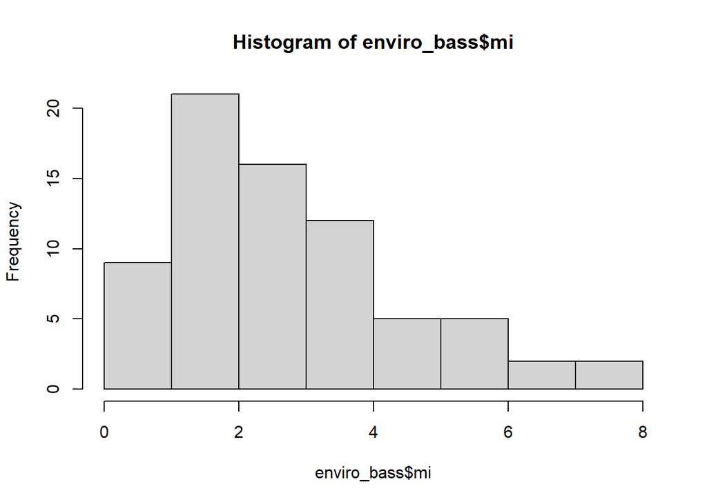

```r
### MI ####
enviro_bass <- enviro_sim %>% mutate(DO_kpa = DO_atm*101.325)
enviro_bass$mi <- MI_calc(A0 = 0.00040728, Bn = 0.01, DO_kPa = enviro_bass$DO_kpa, E0 = 0.27, kB = 0.00008617333262, T_C = enviro_bass$temp)
hist(enviro_bass$mi)
```

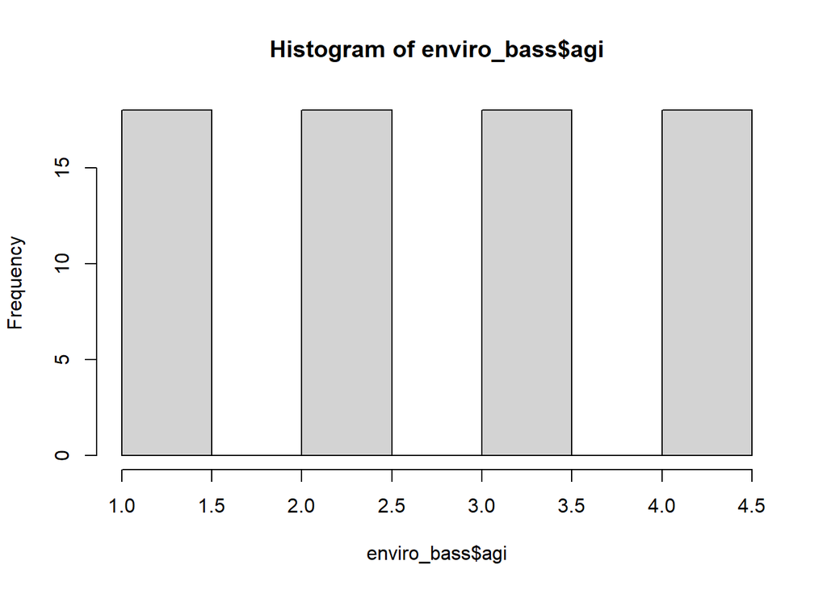

```r
### AGI ####
enviro_bass$agi_o2_demand <- OxyDemand(Tpref = 22, PO2_thresh = DO_thresh, T_C = enviro_bass$temp, W = 498.95, d = 0.700, K = 0.231, Linf = 34.1, LwA = 0.02661, LwB = 2.8)
enviro_bass$agi <- enviro_bass$DO_mbar/enviro_bass$agi_o2_demand
hist(enviro_bass$agi, breaks = 7)
```

**Atlantic cod**

Used same simulated data for both species. Though normative temperatures would be much lower for cod than bass. Weight is average reported online.

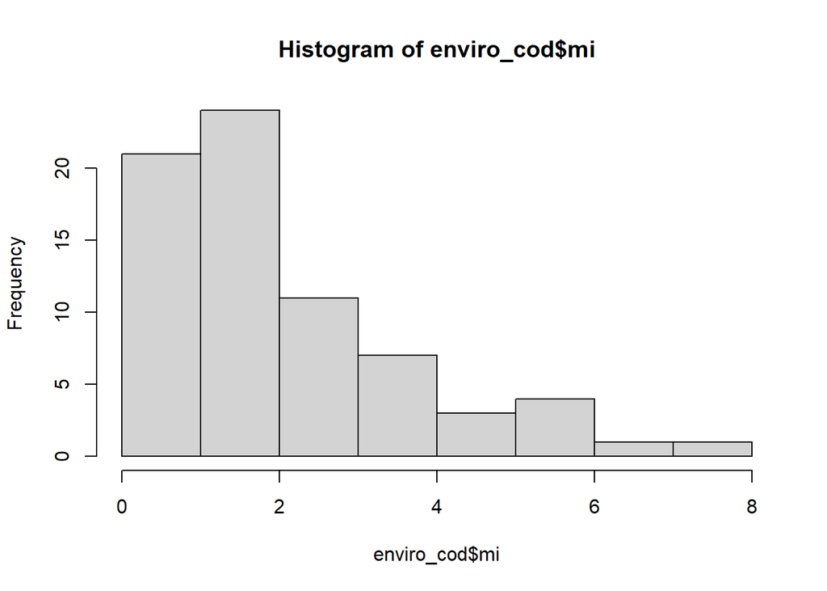

```r
### MI ####
enviro_cod <- enviro_sim %>% mutate(DO_kpa = DO_atm*101.325)
enviro_cod$mi <- MI_calc(A0 = 0.000000668, Bn = 0.01, DO_kPa = enviro_cod$DO_kpa, E0 = 0.42, kB = 0.00008617333262, T_C = enviro_cod$temp)
hist(enviro_cod$mi)
```

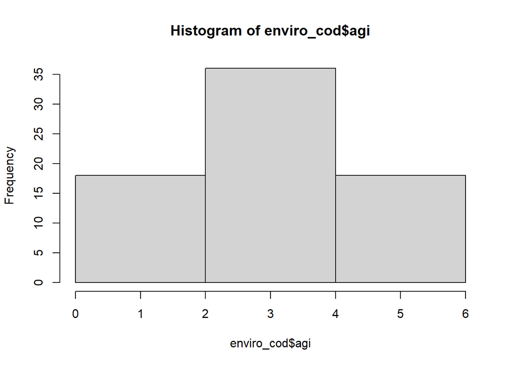

```r
### AGI ####
enviro_cod$agi_o2_demand <- OxyDemand(Tpref = 12, PO2_thresh = DO_thresh, T_C = enviro_cod$temp, W = 39916.1, d = 0.700, K = 0.121, Linf = 148, LwA = 0.005, LwB = 3.185)
enviro_cod$agi <- enviro_cod$DO_mbar/enviro_cod$agi_o2_demand
hist(enviro_cod$agi, breaks = 2)
```

## Size explore (AGI oxygen demand, units: atm)

**Linf (according to von Bertalanffy growth theory)** = NOT the maximum length of the animal. Instead, it is the length a species would reach if it continued to grow indefinitely. Horizontal asymptote of the asymptotic growth curve.

**Winf (according to Fishbase)** = A parameter of the von Bertalanffy Growth Function (VBGF), expressing the mean weight the fish of a given stock would reach if they were to grow for an infinitely long period; also: the weight corresponding to Linf.

**Black sea bass weight**

Min and max weights from the MI study

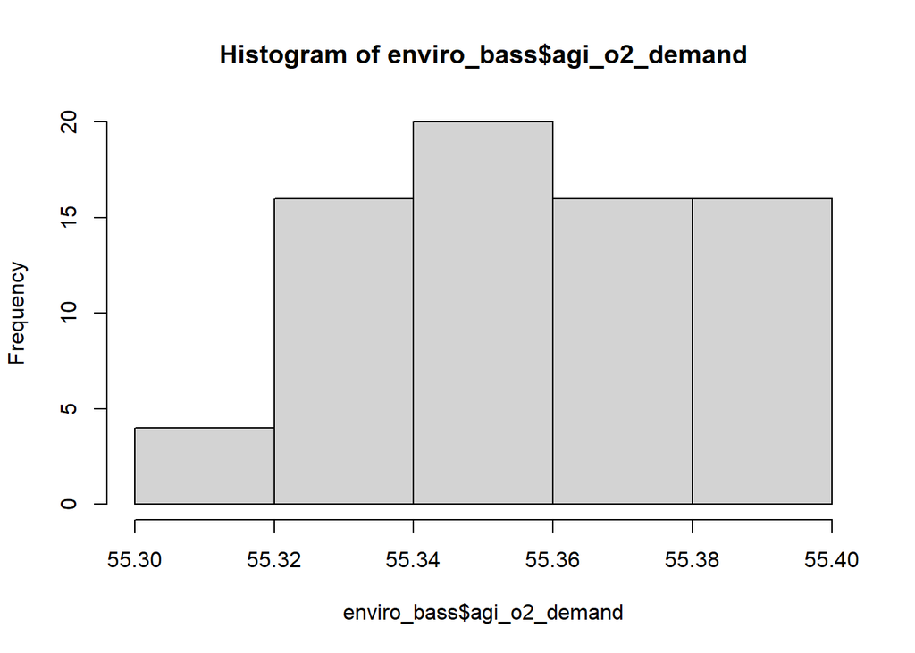

```r
#max weight for species
enviro_bass$agi_o2_demand <- OxyDemand(Tpref = 22, PO2_thresh = DO_thresh, T_C = enviro_bass$temp, W = 700.4, d = 0.700, K = 0.231, Linf = 34.1, LwA = 0.02661, LwB = 2.8)
hist(enviro_bass$agi_o2_demand, breaks = 3)
```

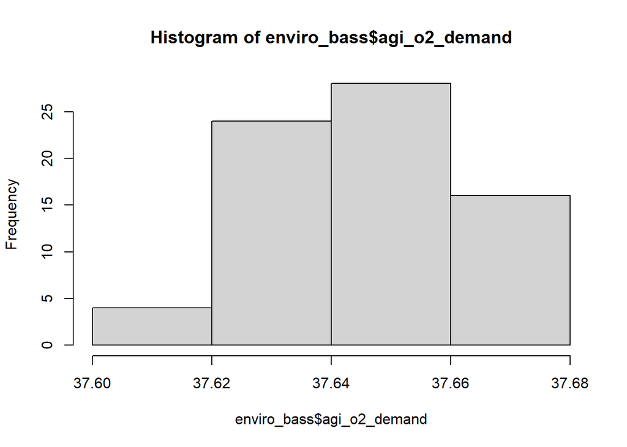

```r
#min weight for species
enviro_bass$agi_o2_demand <- OxyDemand(Tpref = 22, PO2_thresh = DO_thresh, T_C = enviro_bass$temp, W = 193.7, d = 0.700, K = 0.231, Linf = 34.1, LwA = 0.02661, LwB = 2.8)
hist(enviro_bass$agi_o2_demand, breaks = 3)
```

**Atlantic cod weight**

Min and max weights used here are just for **juveniles** included in MI study.

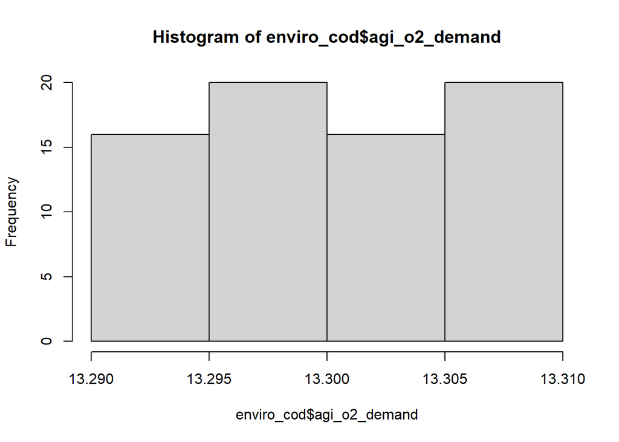

```r
#max weight for species
enviro_cod$agi_o2_demand <- OxyDemand(Tpref = 12, PO2_thresh = DO_thresh, T_C = enviro_cod$temp, W = 473, d = 0.700, K = 0.121, Linf = 148, LwA = 0.005, LwB = 3.185)
hist(enviro_cod$agi_o2_demand, breaks = 4)
```

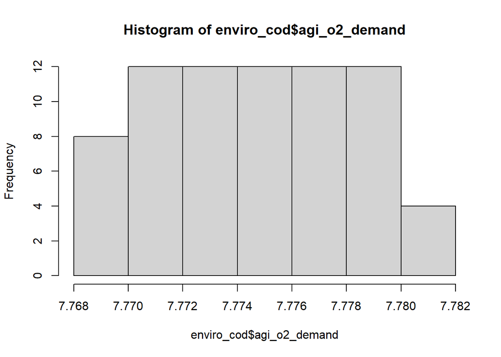

```r
#min weight for species
enviro_cod$agi_o2_demand <- OxyDemand(Tpref = 12, PO2_thresh = DO_thresh, T_C = enviro_cod$temp, W = 79, d = 0.700, K = 0.121, Linf = 148, LwA = 0.005, LwB = 3.185)
hist(enviro_cod$agi_o2_demand, breaks = 4)
```

**Black sea bass length (Winf via Linf)**

Min and max TL from MI study. Weights are average from MI study (Slessinger et al., 2019; 329.9 g)

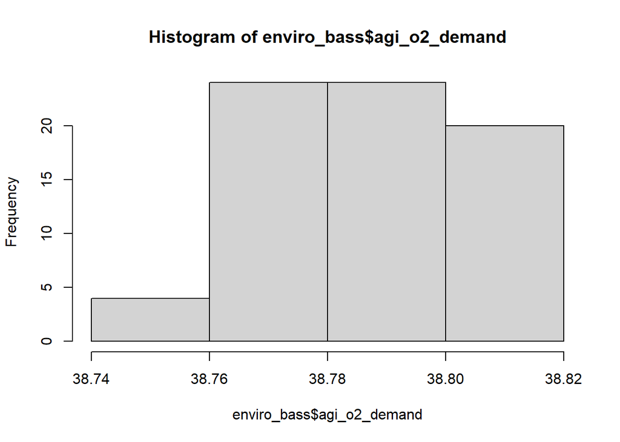

```r
#max length for species -- max weight included in MI study
enviro_bass$agi_o2_demand <- OxyDemand(Tpref = 22, PO2_thresh = DO_thresh, T_C = enviro_bass$temp, W = 329.9, d = 0.700, K = 0.231, Linf = 39.8, LwA = 0.02661, LwB = 2.8)
hist(enviro_bass$agi_o2_demand, breaks = 3)
```

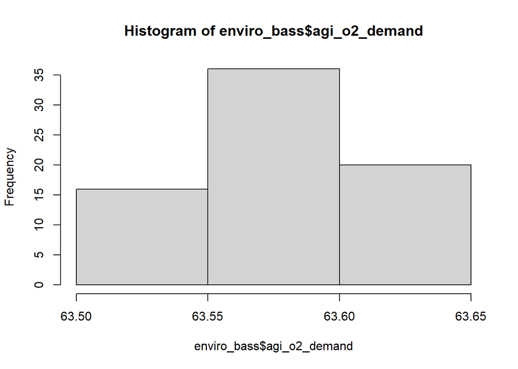

```r
#min length for species -- min weight included in MI study
enviro_bass$agi_o2_demand <- OxyDemand(Tpref = 22, PO2_thresh = DO_thresh, T_C = enviro_bass$temp, W = 329.9, d = 0.700, K = 0.231, Linf = 22.1, LwA = 0.02661, LwB = 2.8)
hist(enviro_bass$agi_o2_demand, breaks = 3)
```

**Atlantic cod length (Winf via Linf)**

Min and max TLs used here are just for juveniles included in MI study. Weights are average from MI study from SMR results at 10C.

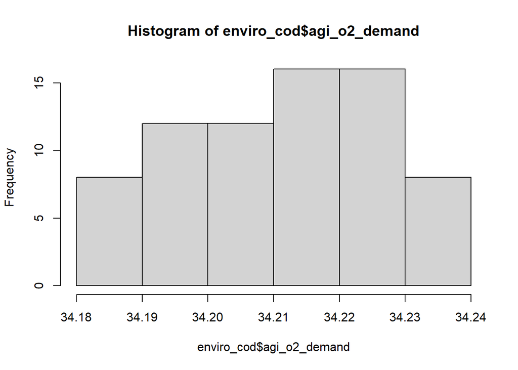

```r
#max length for species -- max weight included in MI study
enviro_cod$agi_o2_demand <- OxyDemand(Tpref = 12, PO2_thresh = DO_thresh, T_C = enviro_cod$temp, W = 157.7, d = 0.700, K = 0.121, Linf = 39, LwA = 0.005, LwB = 3.185)
hist(enviro_cod$agi_o2_demand, breaks = 4)
```

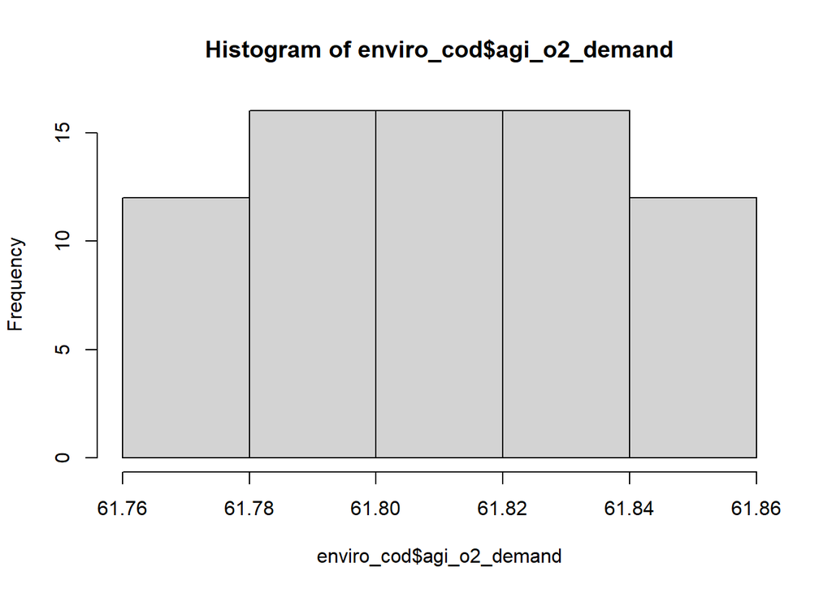

```r
#min length for species -- max weight included in MI study
enviro_cod$agi_o2_demand <- OxyDemand(Tpref = 12, PO2_thresh = DO_thresh, T_C = enviro_cod$temp, W = 157.7, d = 0.700, K = 0.121, Linf = 21, LwA = 0.005, LwB = 3.185)
hist(enviro_cod$agi_o2_demand, breaks = 4)
```

## Temperature sensitivity analysis

Just performed for overall AGI values. Can follow up by focusing on how variations in the numerator or denominator change the AGI output.

**Black sea bass**

Tested how AGI calculations changed with a range of Tpref values. Tested a series of different temperatures within range of those where empirical MI data is available (12 - 30 C).

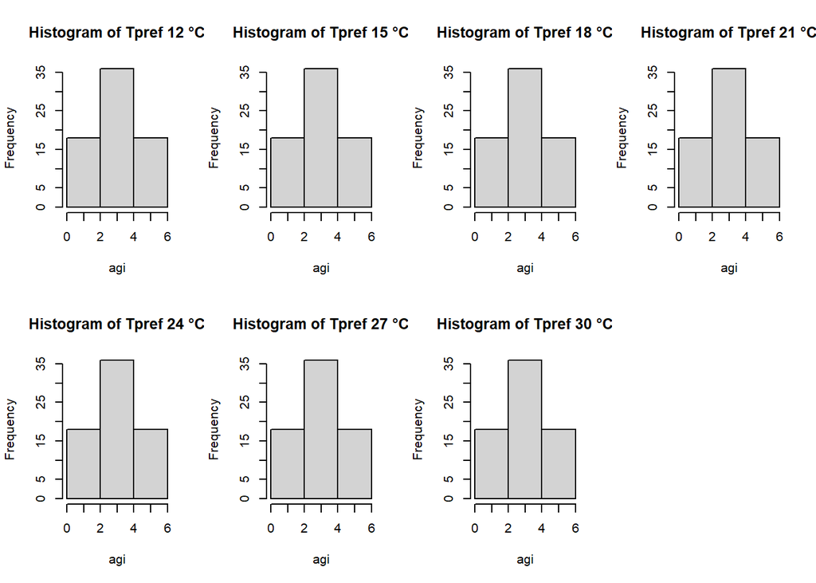

```r
Tpref_vect <- seq(12, 30, by = 3)

hist_list = list()
for(i in 1:length(Tpref_vect)){
  Tpref_temp = Tpref_vect[i]

  agi_o2_demand <- OxyDemand(Tpref = Tpref_temp, PO2_thresh = DO_thresh, T_C = enviro_bass$temp, W = 498.95, d = 0.700, K = 0.231, Linf = 34.1, LwA = 0.02661, LwB = 2.8)

  agi <- enviro_bass$DO_mbar/agi_o2_demand

  hist_list[[i]] <- hist(agi, plot = FALSE, breaks = 2)
}

par(mfrow = c(2, 4))  # Set plotting area to 2 rows x 3 columns

for (i in seq_along(hist_list)) {
  plot(hist_list[[i]], main = paste("Histogram of Tpref", Tpref_vect[i], "°C"))
}
```

**Atlantic cod**

Tested how AGI calculations changed with a range of Tpref values. Tested a series of different temperatures within range of those where empirical MI data is available (5 - 15 C).

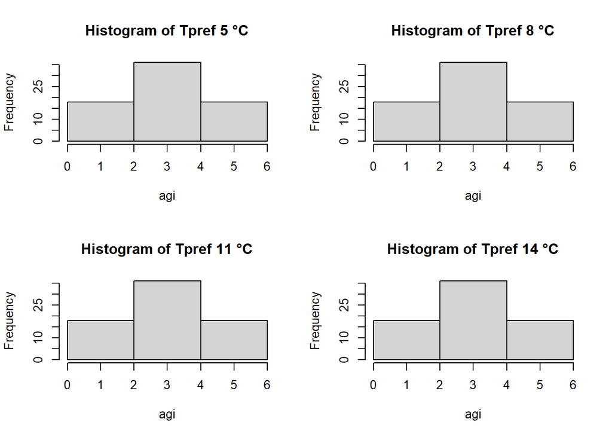

```r
Tpref_vect <- seq(5, 15, by = 3)

hist_list = list()
for(i in 1:length(Tpref_vect)){
  Tpref_temp = Tpref_vect[i]

  agi_o2_demand <- OxyDemand(Tpref = Tpref_temp, PO2_thresh = DO_thresh, T_C = enviro_cod$temp, W = 39916.1, d = 0.700, K = 0.121, Linf = 148, LwA = 0.005, LwB = 3.185)
  agi <- enviro_bass$DO_mbar/agi_o2_demand

  hist_list[[i]] <- hist(agi, plot = FALSE, breaks = 2)
}

par(mfrow = c(2, 2))  # Set plotting area to 2 rows x 3 columns

for (i in seq_along(hist_list)) {
  plot(hist_list[[i]], main = paste("Histogram of Tpref", Tpref_vect[i], "°C"))
}
```

## Calculated metabolic demand (AGI denominator) vs. empirical

**Black sea bass**

Empirical data taken from target temperature binned averages from Slessinger et al., 2019. Sexes were mixed to calculate temperature specific averages. RMR are reported as mg O2/hr/kg. AGI-MR values are in atm.

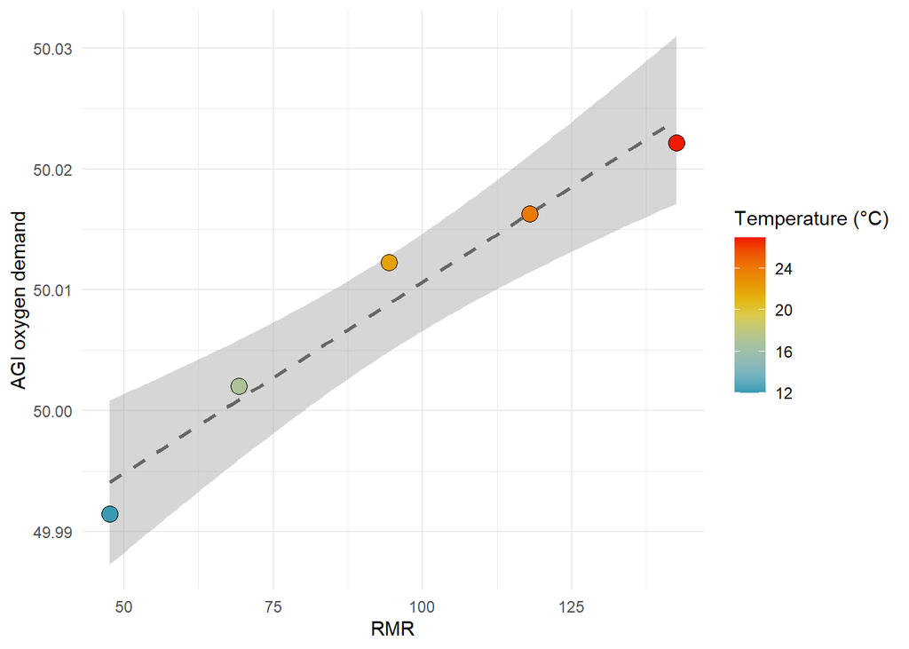

```r
par(mfrow = c(1,1))

emp_bass_test <- data.frame(temp = as.numeric(c(12, 17, 22, 24, 27)),
                           RMR = as.numeric(c(47.68, 69.28, 94.42, 117.93, 142.5)))

emp_bass_test$agi_o2_demand <- OxyDemand(Tpref = 22, PO2_thresh = DO_thresh, T_C = emp_bass_test$temp, W = 498.95, d = 0.700, K = 0.231, Linf = 34.1, LwA = 0.02661, LwB = 2.8)

ggplot(emp_bass_test, aes(x = RMR, y = agi_o2_demand, fill = temp)) +
  geom_smooth(method = "lm", linetype = "dashed", color = "gray40") +  # 1:1 line
  geom_point(shape = 21, size = 4, color = "black") +
  scale_fill_gradientn(colors = wes_palette("Zissou1", 100, type = "continuous")) +
  theme_minimal() +
  labs(
    x = "RMR",
    y = "AGI oxygen demand",
    fill = "Temperature (°C)"
  )
```

```r
bass_mod <- lm(agi_o2_demand ~ RMR, emp_bass_test)
summary(bass_mod) #R2 = 0.9605
```

```
Call:
lm(formula = agi_o2_demand ~ RMR, data = emp_bass_test)

Residuals:
         1          2          3          4          5
-0.0026019  0.0011418  0.0034098 -0.0000338 -0.0019159

Coefficients:
             Estimate Std. Error  t value Pr(>|t|)
(Intercept) 4.998e+01  3.711e-03 13469.09 9.03e-13 ***
RMR         3.163e-04  3.703e-05     8.54  0.00337 **
---
Signif. codes:  0 '***' 0.001 '**' 0.01 '*' 0.05 '.' 0.1 ' ' 1

Residual standard error: 0.002791 on 3 degrees of freedom
Multiple R-squared:  0.9605,    Adjusted R-squared:  0.9473
F-statistic: 72.94 on 1 and 3 DF,  p-value: 0.003373
```

**Atlantic cod**

Empirical data taken from target temperature binned averages from Schurmann and Steffensen 1997. Values were pulled from table 1 of the paper. RMR are reported as mg O2/hr/kg. AGI-MR values are in atm.

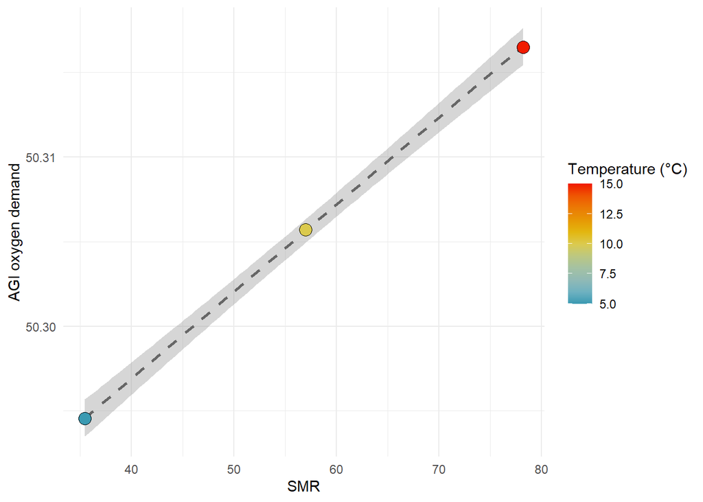

```r
emp_cod_test <- data.frame(temp = as.numeric(c(5, 10, 15)),
                           SMR = as.numeric(c(35.5, 57, 78.2)))

emp_cod_test$agi_o2_demand <- OxyDemand(Tpref = 12, PO2_thresh = DO_thresh, T_C = emp_cod_test$temp, W = 39916.1, d = 0.700, K = 0.121, Linf = 148, LwA = 0.005, LwB = 3.185)

ggplot(emp_cod_test, aes(x = SMR, y = agi_o2_demand, fill = temp)) +
  geom_smooth(method = "lm", linetype = "dashed", color = "gray40") +  # 1:1 line
  geom_point(shape = 21, size = 4, color = "black") +
  scale_fill_gradientn(colors = wes_palette("Zissou1", 100, type = "continuous")) +
  theme_minimal() +
  labs(
    x = "SMR",
    y = "AGI oxygen demand",
    fill = "Temperature (°C)"
  )
```

```r
cod_mod <- lm(agi_o2_demand ~ SMR, emp_cod_test)
summary(cod_mod) #R2 = 1
```

```
Call:
lm(formula = agi_o2_demand ~ SMR, data = emp_cod_test)

Residuals:
         1          2          3
-3.826e-05  7.706e-05 -3.880e-05

Coefficients:
             Estimate Std. Error  t value Pr(>|t|)
(Intercept) 5.028e+01  1.860e-04 270281.2 2.36e-06 ***
SMR         5.145e-04  3.126e-06    164.6  0.00387 **
---
Signif. codes:  0 '***' 0.001 '**' 0.01 '*' 0.05 '.' 0.1 ' ' 1

Residual standard error: 9.438e-05 on 1 degrees of freedom
Multiple R-squared:      1, Adjusted R-squared:  0.9999
F-statistic: 2.709e+04 on 1 and 1 DF,  p-value: 0.003868
```

## AGI & MI tile plots

**Black sea bass**

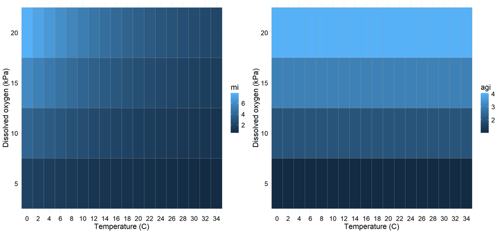

```r
enviro_bass <- enviro_bass %>% mutate(DO_whole = round(DO_kpa), temp_whole = round(temp))
#enviro_bass$temp_bin <- cut(enviro_bass$temp_whole, breaks = 12, labels = seq(from = 0, to = 35, by = 3))
#enviro_bass$DO_bin <- cut(enviro_bass$DO_whole, breaks = 6, labels = seq(from = 5, to = 21, by = 3))

#mi plot
mi_tile <- ggplot(enviro_bass, aes(x = as.factor(temp_whole), y = as.factor(DO_whole), fill = mi)) +
  geom_tile(color = "grey60") +
  ylab("Dissolved oxygen (kPa)") +
  xlab("Temperature (C)") +
  theme_custom()

#agi
agi_tile <- ggplot(enviro_bass, aes(x = as.factor(temp_whole), y = as.factor(DO_whole), fill = agi)) +
  geom_tile(color = "grey60") +
  ylab("Dissolved oxygen (kPa)") +
  xlab("Temperature (C)") +
  theme_custom()

ggpubr::ggarrange(mi_tile, agi_tile)
```

**Atlantic cod**

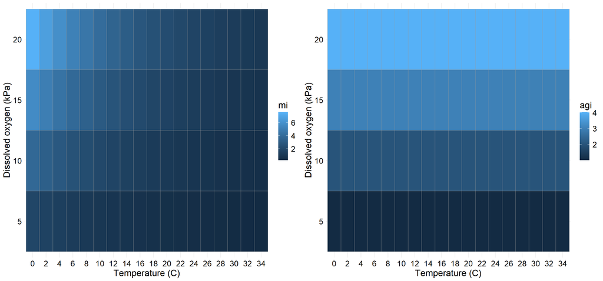

```r
enviro_cod <- enviro_cod %>% mutate(DO_whole = round(DO_kpa), temp_whole = round(temp))
#enviro_cod$temp_whole <- cut(enviro_cod$temp_whole, breaks = 12, labels = seq(from = 0, to = 35, by = 3))
#enviro_cod$DO_whole <- cut(enviro_cod$DO_whole, breaks = 6, labels = seq(from = 5, to = 21, by = 3))


#mi plot
mi_tile <- ggplot(enviro_cod, aes(x = as.factor(temp_whole), y = as.factor(DO_whole), fill = mi)) +
  geom_tile(color = "grey60") +
  ylab("Dissolved oxygen (kPa)") +
  xlab("Temperature (C)") +
  theme_custom()

#agi
agi_tile <- ggplot(enviro_cod, aes(x = as.factor(temp_whole), y = as.factor(DO_whole), fill = agi)) +
  geom_tile(color = "grey60") +
  ylab("Dissolved oxygen (kPa)") +
  xlab("Temperature (C)") +
  theme_custom()

ggpubr::ggarrange(mi_tile, agi_tile)
```

**MI crit**

Comparing MIcrit values as reported in Slessinger et al., 2024 reported for stocks along the NE shelf to scaled MIcrit values used by Deutsch et al., 2020.

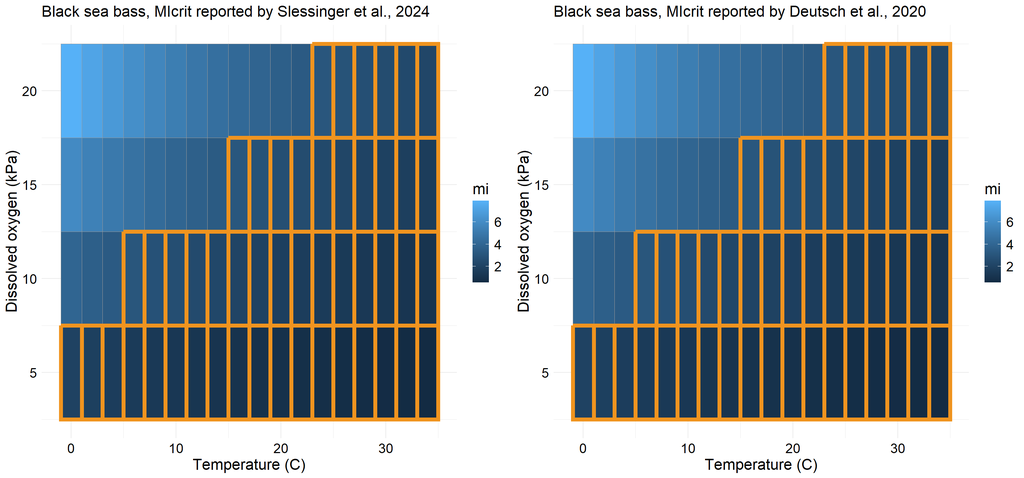

```r
#bass - ES
mi_bass_1_es <- ggplot(enviro_bass, aes(x = temp_whole, y = DO_whole, fill = mi)) +
  geom_tile(color = "grey60") +
  geom_rect(data = filter(enviro_bass, mi < 3.27),
            aes(xmin = as.numeric(temp_whole) - 1,
                xmax = as.numeric(temp_whole) + 1,
                ymin = as.numeric(DO_whole) - 2.5,
                ymax = as.numeric(DO_whole) + 2.5),
            fill = NA,
            color = "#F0941F",
            linewidth = 2,
            inherit.aes = FALSE) +
  ggtitle("Black sea bass, MIcrit reported by Slessinger et al., 2024") +
  ylab("Dissolved oxygen (kPa)") +
  xlab("Temperature (C)") +
  theme_custom()

#bass - CD
mi_bass_1_cd <- ggplot(enviro_bass, aes(x = temp_whole, y = DO_whole, fill = mi)) +
  geom_tile(color = "grey60") +
  geom_rect(data = filter(enviro_bass, mi < 3.28), #range was 3.27-3.29 so I selected middle value
            aes(xmin = as.numeric(temp_whole) - 1,
                xmax = as.numeric(temp_whole) + 1,
                ymin = as.numeric(DO_whole) - 2.5,
                ymax = as.numeric(DO_whole) + 2.5),
            fill = NA,
            color = "#F0941F",
            linewidth = 2,
            inherit.aes = FALSE) +
  ggtitle("Black sea bass, MIcrit reported by Deutsch et al., 2020") +
  ylab("Dissolved oxygen (kPa)") +
  xlab("Temperature (C)") +
  theme_custom()

#cod - ES
mi_cod_1_es <- ggplot(enviro_cod, aes(x = temp_whole, y = DO_whole, fill = mi)) +
  geom_tile(color = "grey60") +
  geom_rect(data = filter(enviro_cod, mi < 2.8),
            aes(xmin = as.numeric(temp_whole) - 1,
                xmax = as.numeric(temp_whole) + 1,
                ymin = as.numeric(DO_whole) - 2.5,
                ymax = as.numeric(DO_whole) + 2.5),
            fill = NA,
            color = "#F0941F",
            linewidth = 2,
            inherit.aes = FALSE) +
  ggtitle("Atlantic cod, MIcrit reported by Slessinger et al., 2024") +
  ylab("Dissolved oxygen (kPa)") +
  xlab("Temperature (C)") +
  theme_custom()

#cod - CD
mi_cod_1_cd <- ggplot(enviro_cod, aes(x = temp_whole, y = DO_whole, fill = mi)) +
  geom_tile(color = "grey60") +
  geom_rect(data = filter(enviro_cod, mi < 2.4),
            aes(xmin = as.numeric(temp_whole) - 1,
                xmax = as.numeric(temp_whole) + 1,
                ymin = as.numeric(DO_whole) - 2.5,
                ymax = as.numeric(DO_whole) + 2.5),
            fill = NA,
            color = "#F0941F",
            linewidth = 2,
            inherit.aes = FALSE) +
  ggtitle("Atlantic cod, MIcrit reported by Deutsch et al., 2020") +
  ylab("Dissolved oxygen (kPa)") +
  xlab("Temperature (C)") +
  theme_custom()

ggpubr::ggarrange(mi_bass_1_es, mi_bass_1_cd)
```

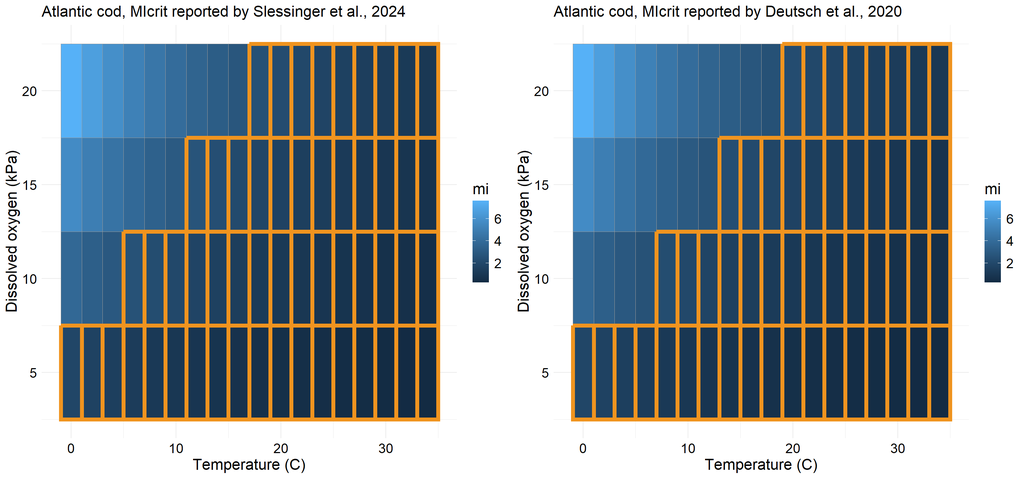

```r
ggpubr::ggarrange(mi_cod_1_es, mi_cod_1_cd)
```

**AGI crit**

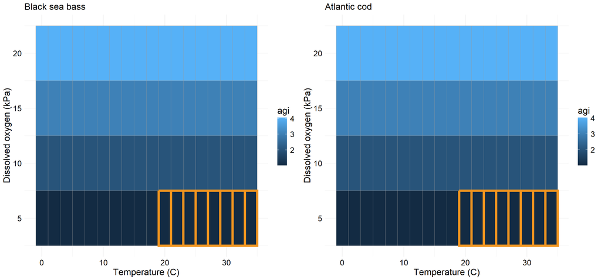

```r
#bass
agi_bass_1 <- ggplot(enviro_bass, aes(x = temp_whole, y = DO_whole, fill = agi)) +
  geom_tile(color = "grey60") +
  geom_rect(data = subset(enviro_bass, agi < quantile(agi, 0.10)),
            aes(xmin = as.numeric(temp_whole) - 1,
                xmax = as.numeric(temp_whole) + 1,
                ymin = as.numeric(DO_whole) - 2.5,
                ymax = as.numeric(DO_whole) + 2.5),
            fill = NA,
            color = "#F0941F",
            linewidth = 2,
            inherit.aes = FALSE) +
  ggtitle("Black sea bass") +
  ylab("Dissolved oxygen (kPa)") +
  xlab("Temperature (C)") +
  theme_custom()

#cod
agi_cod_1 <- ggplot(enviro_cod, aes(x = temp_whole, y = DO_whole, fill = agi)) +
  geom_tile(color = "grey60") +
  geom_rect(data = subset(enviro_cod, agi < quantile(agi, 0.10)),
            aes(xmin = as.numeric(temp_whole) - 1,
                xmax = as.numeric(temp_whole) + 1,
                ymin = as.numeric(DO_whole) - 2.5,
                ymax = as.numeric(DO_whole) + 2.5),
            fill = NA,
            color = "#F0941F",
            linewidth = 2,
            inherit.aes = FALSE) +
  ggtitle("Atlantic cod") +
  ylab("Dissolved oxygen (kPa)") +
  xlab("Temperature (C)") +
  theme_custom()

ggpubr::ggarrange(agi_bass_1, agi_cod_1)
```

**AGI bass sizes**

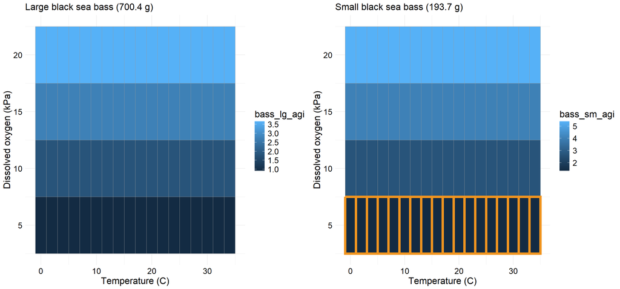

```r
enviro_bass_size <- enviro_bass %>%
  mutate(bass_lg_demand = OxyDemand(Tpref = 22, PO2_thresh = DO_thresh, T_C = enviro_bass$temp, W = 700.4, d = 0.700, K = 0.231, Linf = 34.1, LwA = 0.02661, LwB = 2.8),
         bass_lg_agi = DO_mbar/bass_lg_demand,
         bass_sm_demand = OxyDemand(Tpref = 22, PO2_thresh = DO_thresh, T_C = enviro_bass$temp, W = 193.7, d = 0.700, K = 0.231, Linf = 34.1, LwA = 0.02661, LwB = 2.8),
         bass_sm_agi = DO_mbar/bass_sm_demand)


#bass large
agi_bass_lg <- ggplot(enviro_bass_size, aes(x = temp_whole, y = DO_whole, fill = bass_lg_agi)) +
  geom_tile(color = "grey60") +
  geom_rect(data = subset(enviro_bass_size, agi < quantile(bass_lg_agi, 0.10)),
            aes(xmin = as.numeric(temp_whole) - 1,
                xmax = as.numeric(temp_whole) + 1,
                ymin = as.numeric(DO_whole) - 2.5,
                ymax = as.numeric(DO_whole) + 2.5),
            fill = NA,
            color = "#F0941F",
            linewidth = 2,
            inherit.aes = FALSE) +
  ggtitle("Large black sea bass (700.4 g)") +
  ylab("Dissolved oxygen (kPa)") +
  xlab("Temperature (C)") +
  theme_custom()

#bass small
agi_bass_sm <- ggplot(enviro_bass_size, aes(x = temp_whole, y = DO_whole, fill = bass_sm_agi)) +
  geom_tile(color = "grey60") +
  geom_rect(data = subset(enviro_bass_size, agi < quantile(bass_sm_agi, 0.10)),
            aes(xmin = as.numeric(temp_whole) - 1,
                xmax = as.numeric(temp_whole) + 1,
                ymin = as.numeric(DO_whole) - 2.5,
                ymax = as.numeric(DO_whole) + 2.5),
            fill = NA,
            color = "#F0941F",
            linewidth = 2,
            inherit.aes = FALSE) +
  ggtitle("Small black sea bass (193.7 g)") +
  ylab("Dissolved oxygen (kPa)") +
  xlab("Temperature (C)") +
  theme_custom()

ggpubr::ggarrange(agi_bass_lg, agi_bass_sm)
```

## AGI ~ temperature scatter

Kept DO at normoxia (0.21 atm) when calculating the AGI. **NOTE** something strange happening with y-axis when rendering html document.

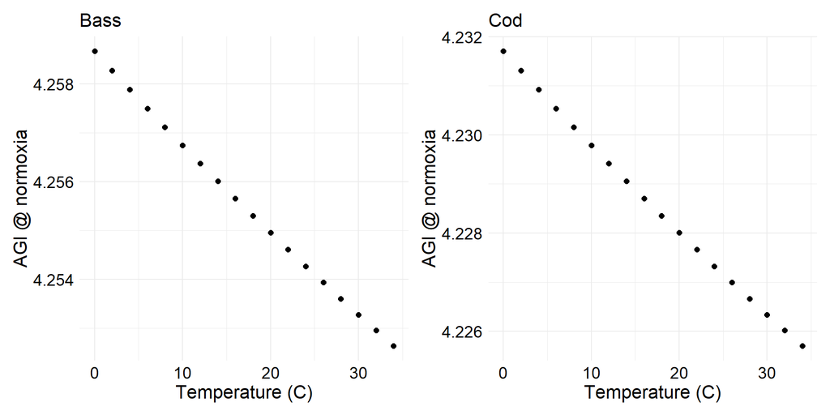

```r
#bass
enviro_bass$agi_normoxia <- 0.21*1013.25/enviro_bass$agi_o2_demand

bass_norm <- ggplot(enviro_bass, aes(temp, agi_normoxia)) +
  geom_point(size = 2, color = "black") +
  xlab("Temperature (C)") +
  ylab("AGI @ normoxia") +
  #coord_cartesian(ylim = c(5.4815, 5.490)) +
  ggtitle("Bass") +
  theme_custom()

#cod
enviro_cod$agi_normoxia <- 0.21*1013.25/enviro_cod$agi_o2_demand

cod_norm <- ggplot(enviro_cod, aes(temp, agi_normoxia)) +
  geom_point(size = 2, color = "black") +
  xlab("Temperature (C)") +
  ylab("AGI @ normoxia") +
  ggtitle("Cod") +
  theme_custom()

bass_norm | cod_norm
```

## AGI ~ MI

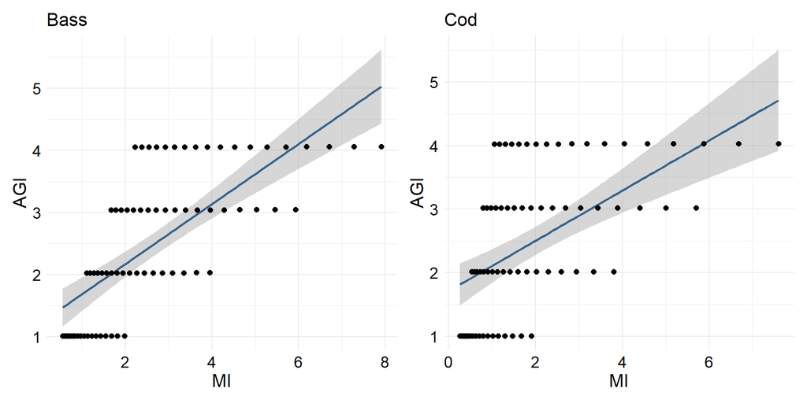

```r
#bass
bass_mi_agi <- ggplot(enviro_bass, aes(mi, agi)) +
  stat_smooth(method = "lm", col = "steelblue4") +
  geom_point(size = 2, color = "black") +
  xlab("MI") +
  ylab("AGI") +
  #coord_cartesian(ylim = c(1, 4.2)) +
  ggtitle("Bass") +
  theme_custom()

#cod
cod_mi_agi <- ggplot(enviro_cod, aes(mi, agi)) +
  stat_smooth(method = "lm", col = "steelblue4") +
  geom_point(size = 2, color = "black") +
  xlab("MI") +
  ylab("AGI") +
  #coord_cartesian(ylim = c(1, 4.2)) +
  ggtitle("Cod") +
  theme_custom()

bass_mi_agi | cod_mi_agi
```

```r
cod_mod <- lm(agi ~ mi, data = enviro_cod); summary(cod_mod)
```

```
Call:
lm(formula = agi ~ mi, data = enviro_cod)

Residuals:
     Min       1Q   Median       3Q      Max
-1.45467 -0.85049 -0.07475  0.73234  1.89625

Coefficients:
            Estimate Std. Error t value Pr(>|t|)
(Intercept)  1.71177    0.17875   9.577 2.34e-14 ***
mi           0.39502    0.06876   5.745 2.20e-07 ***
---
Signif. codes:  0 '***' 0.001 '**' 0.01 '*' 0.05 '.' 0.1 ' ' 1

Residual standard error: 0.9411 on 70 degrees of freedom
Multiple R-squared:  0.3204,    Adjusted R-squared:  0.3107
F-statistic:    33 on 1 and 70 DF,  p-value: 2.197e-07
```

```r
bass_mod <- lm(agi ~ mi, data = enviro_bass); summary(bass_mod)
```

```
Call:
lm(formula = agi ~ mi, data = enviro_bass)

Residuals:
    Min      1Q  Median      3Q     Max
-1.1417 -0.6321 -0.1236  0.5511  1.7763

Coefficients:
            Estimate Std. Error t value Pr(>|t|)
(Intercept)  1.19985    0.17742   6.763 3.37e-09 ***
mi           0.48323    0.05473   8.829 5.46e-13 ***
---
Signif. codes:  0 '***' 0.001 '**' 0.01 '*' 0.05 '.' 0.1 ' ' 1

Residual standard error: 0.7903 on 70 degrees of freedom
Multiple R-squared:  0.5268,    Adjusted R-squared:  0.5201
F-statistic: 77.94 on 1 and 70 DF,  p-value: 5.455e-13
```

## AGI/MI ~ temp.

**Bass**

```r
#bass, mi
bass_mi_temp <- ggplot(enviro_bass, aes(temp, mi, fill = DO_mbar)) +
  stat_smooth(method = "lm", col = "steelblue4") +
  geom_point(size = 3, color = "black", shape = 21) +
  xlab("Temperature (C)") +
  ylab("MI") +
  #coord_cartesian(ylim = c(1, 4.2)) +
  ggtitle("Bass, MI") +
  theme_custom()

bass_mod_mi_temp <- lm(mi ~ temp, data = enviro_bass); summary(bass_mod_mi_temp)
```

```
Call:
lm(formula = mi ~ temp, data = enviro_bass)

Residuals:
    Min      1Q  Median      3Q     Max
-2.4978 -0.8112  0.1632  1.0767  3.4364

Coefficients:
            Estimate Std. Error t value Pr(>|t|)
(Intercept)  4.47582    0.30756   14.55  < 2e-16 ***
temp        -0.10099    0.01544   -6.54 8.52e-09 ***
---
Signif. codes:  0 '***' 0.001 '**' 0.01 '*' 0.05 '.' 0.1 ' ' 1

Residual standard error: 1.36 on 70 degrees of freedom
Multiple R-squared:  0.3793,    Adjusted R-squared:  0.3704
F-statistic: 42.77 on 1 and 70 DF,  p-value: 8.525e-09
```

```r
#bass, agi
bass_agi_temp <- ggplot(enviro_bass, aes(temp, agi, fill = DO_mbar)) +
  stat_smooth(method = "lm", col = "steelblue4") +
  geom_point(size = 3, color = "black", shape = 21) +
  xlab("Temperature (C)") +
  ylab("AGI") +
  #coord_cartesian(ylim = c(1, 4.2)) +
  ggtitle("Bass, AGI") +
  theme_custom()

bass_mod_agi_temp <- lm(agi ~ temp, data = enviro_bass); summary(bass_mod_agi_temp)
```

```
Call:
lm(formula = agi ~ temp, data = enviro_bass)

Residuals:
     Min       1Q   Median       3Q      Max
-1.52089 -0.75987  0.00006  0.76001  1.52102

Coefficients:
              Estimate Std. Error t value Pr(>|t|)
(Intercept)  2.5348548  0.2598865   9.754 1.12e-14 ***
temp        -0.0001056  0.0130488  -0.008    0.994
---
Signif. codes:  0 '***' 0.001 '**' 0.01 '*' 0.05 '.' 0.1 ' ' 1

Residual standard error: 1.149 on 70 degrees of freedom
Multiple R-squared:  9.348e-07, Adjusted R-squared:  -0.01428
F-statistic: 6.543e-05 on 1 and 70 DF,  p-value: 0.9936
```

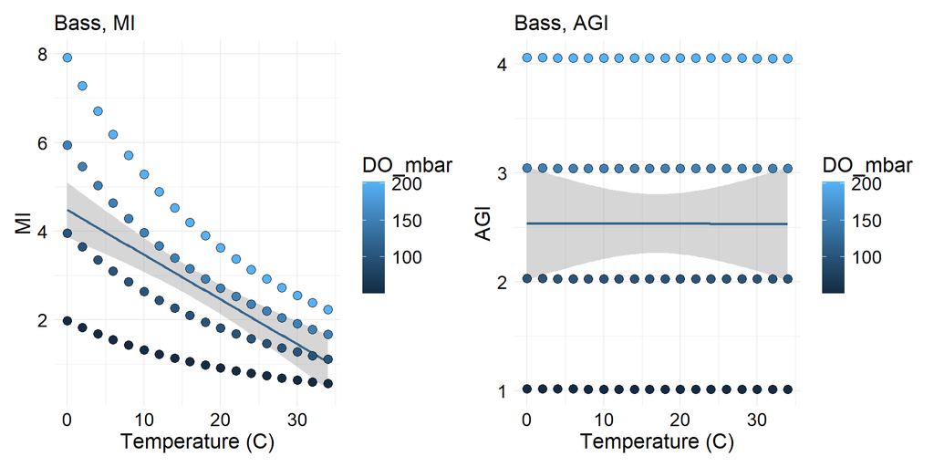

```r
bass_mi_temp | bass_agi_temp
```

**Cod**

```r
#cod, mi
cod_mi_temp <- ggplot(enviro_cod, aes(temp, mi, fill = DO_mbar)) +
  stat_smooth(method = "lm", col = "steelblue4") +
  geom_point(size = 3, color = "black", shape = 21) +
  xlab("Temperature (C)") +
  ylab("MI") +
  #coord_cartesian(ylim = c(1, 4.2)) +
  ggtitle("Cod, MI") +
  theme_custom()

cod_mod_mi_temp <- lm(mi ~ temp, data = enviro_cod); summary(cod_mod_mi_temp)
```

```
Call:
lm(formula = mi ~ temp, data = enviro_cod)

Residuals:
    Min      1Q  Median      3Q     Max
-2.0520 -0.6959  0.0212  0.5994  3.6542

Coefficients:
            Estimate Std. Error t value Pr(>|t|)
(Intercept)  3.94504    0.25625  15.395  < 2e-16 ***
temp        -0.11215    0.01287  -8.716 8.77e-13 ***
---
Signif. codes:  0 '***' 0.001 '**' 0.01 '*' 0.05 '.' 0.1 ' ' 1

Residual standard error: 1.133 on 70 degrees of freedom
Multiple R-squared:  0.5205,    Adjusted R-squared:  0.5136
F-statistic: 75.98 on 1 and 70 DF,  p-value: 8.766e-13
```

```r
#cod, agi
cod_agi_temp <- ggplot(enviro_cod, aes(temp, agi, fill = DO_mbar)) +
  stat_smooth(method = "lm", col = "steelblue4") +
  geom_point(size = 3, color = "black", shape = 21) +
  xlab("Temperature (C)") +
  ylab("AGI") +
  #coord_cartesian(ylim = c(1, 4.2)) +
  ggtitle("Cod, AGI") +
  theme_custom()

cod_mod_agi_temp <- lm(agi ~ temp, data = enviro_cod); summary(cod_mod_agi_temp)
```

```
Call:
lm(formula = agi ~ temp, data = enviro_cod)

Residuals:
     Min       1Q   Median       3Q      Max
-1.51125 -0.75506  0.00006  0.75519  1.51139

Coefficients:
              Estimate Std. Error t value Pr(>|t|)
(Intercept)  2.5188023  0.2582408   9.754 1.12e-14 ***
temp        -0.0001049  0.0129662  -0.008    0.994
---
Signif. codes:  0 '***' 0.001 '**' 0.01 '*' 0.05 '.' 0.1 ' ' 1

Residual standard error: 1.142 on 70 degrees of freedom
Multiple R-squared:  9.348e-07, Adjusted R-squared:  -0.01428
F-statistic: 6.543e-05 on 1 and 70 DF,  p-value: 0.9936
```

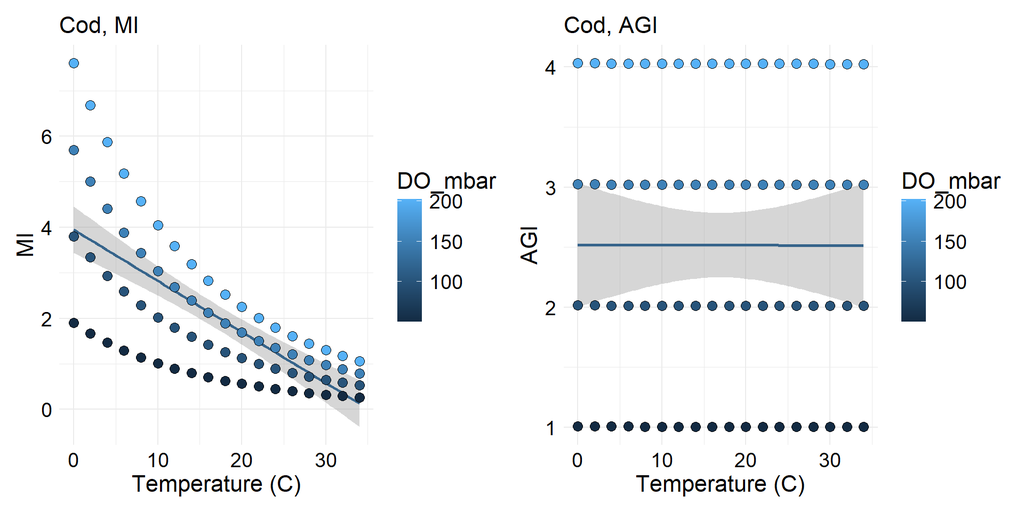

```r
cod_mi_temp | cod_agi_temp
```

## AGI/MI ~ DO

**Bass**

```r
#bass, mi
bass_mi_do <- ggplot(enviro_bass, aes(DO_kpa, mi, fill = temp)) +
  stat_smooth(method = "lm", col = "steelblue4") +
  geom_point(size = 3, color = "black", shape = 21) +
  xlab("DO (kPa)") +
  ylab("MI") +
  #coord_cartesian(ylim = c(1, 4.2)) +
  ggtitle("Bass, MI") +
  theme_custom()

bass_mod_mi_do <- lm(mi ~ DO_kpa, data = enviro_bass); summary(bass_mod_mi_do)
```

```
Call:
lm(formula = mi ~ DO_kpa, data = enviro_bass)

Residuals:
    Min      1Q  Median      3Q     Max
-2.1918 -0.7895 -0.1822  0.6469  3.4979

Coefficients:
             Estimate Std. Error t value Pr(>|t|)
(Intercept) 8.374e-16  3.430e-01    0.00        1
DO_kpa      2.178e-01  2.473e-02    8.81  5.9e-13 ***
---
Signif. codes:  0 '***' 0.001 '**' 0.01 '*' 0.05 '.' 0.1 ' ' 1

Residual standard error: 1.188 on 70 degrees of freedom
Multiple R-squared:  0.5258,    Adjusted R-squared:  0.519
F-statistic: 77.62 on 1 and 70 DF,  p-value: 5.898e-13
```

```r
#bass, agi
bass_agi_do <- ggplot(enviro_bass, aes(DO_mbar, agi, fill = temp)) +
  stat_smooth(method = "lm", col = "steelblue4") +
  geom_point(size = 3, color = "black", shape = 21) +
  xlab("DO (atm)") +
  ylab("AGI") +
  #coord_cartesian(ylim = c(1, 4.2)) +
  ggtitle("Bass, AGI") +
  theme_custom()

bass_mod_agi_do <- lm(agi ~ DO_mbar, data = enviro_bass); summary(bass_mod_agi_do)
```

```
Call:
lm(formula = agi ~ DO_mbar, data = enviro_bass)

Residuals:
       Min         1Q     Median         3Q        Max
-2.768e-03 -7.107e-04 -1.562e-05  7.467e-04  2.981e-03

Coefficients:
              Estimate Std. Error t value Pr(>|t|)
(Intercept) -3.768e-15  3.514e-04       0        1
DO_mbar      2.000e-02  2.533e-06    7896   <2e-16 ***
---
Signif. codes:  0 '***' 0.001 '**' 0.01 '*' 0.05 '.' 0.1 ' ' 1

Residual standard error: 0.001217 on 70 degrees of freedom
Multiple R-squared:      1, Adjusted R-squared:      1
F-statistic: 6.234e+07 on 1 and 70 DF,  p-value: < 2.2e-16
```

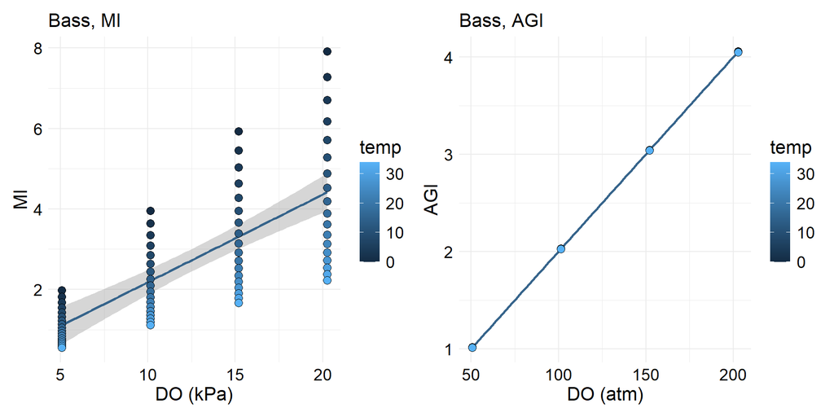

```r
bass_mi_do | bass_agi_do
```

**Cod**

```r
#cod, mi
cod_mi_do <- ggplot(enviro_cod, aes(DO_kpa, mi, fill = temp)) +
  stat_smooth(method = "lm", col = "steelblue4") +
  geom_point(size = 3, color = "black", shape = 21) +
  xlab("DO (kPa)") +
  ylab("MI") +
  #coord_cartesian(ylim = c(1, 4.2)) +
  ggtitle("Cod, MI") +
  theme_custom()

cod_mod_mi_do <- lm(mi ~ DO_kpa, data = enviro_cod); summary(cod_mod_mi_do)
```

```
Call:
lm(formula = mi ~ DO_kpa, data = enviro_cod)

Residuals:
    Min      1Q  Median      3Q     Max
-2.2073 -0.9155 -0.2830  0.6538  4.3376

Coefficients:
             Estimate Std. Error t value Pr(>|t|)
(Intercept) 4.187e-16  3.896e-01   0.000        1
DO_kpa      1.609e-01  2.808e-02   5.732 2.31e-07 ***
---
Signif. codes:  0 '***' 0.001 '**' 0.01 '*' 0.05 '.' 0.1 ' ' 1

Residual standard error: 1.35 on 70 degrees of freedom
Multiple R-squared:  0.3194,    Adjusted R-squared:  0.3097
F-statistic: 32.86 on 1 and 70 DF,  p-value: 2.311e-07
```

```r
#cod, agi
cod_agi_do <- ggplot(enviro_cod, aes(DO_mbar, agi, fill = temp)) +
  stat_smooth(method = "lm", col = "steelblue4") +
  geom_point(size = 3, color = "black", shape = 21) +
  xlab("DO (atm)") +
  ylab("AGI") +
  #coord_cartesian(ylim = c(1, 4.2)) +
  ggtitle("Cod, AGI") +
  theme_custom()

cod_mod_agi_do <- lm(agi ~ DO_mbar, data = enviro_cod); summary(cod_mod_agi_do)
```

```
Call:
lm(formula = agi ~ DO_mbar, data = enviro_cod)

Residuals:
       Min         1Q     Median         3Q        Max
-2.750e-03 -7.062e-04 -1.552e-05  7.419e-04  2.962e-03

Coefficients:
              Estimate Std. Error t value Pr(>|t|)
(Intercept) -3.768e-15  3.492e-04       0        1
DO_mbar      1.987e-02  2.517e-06    7896   <2e-16 ***
---
Signif. codes:  0 '***' 0.001 '**' 0.01 '*' 0.05 '.' 0.1 ' ' 1

Residual standard error: 0.00121 on 70 degrees of freedom
Multiple R-squared:      1, Adjusted R-squared:      1
F-statistic: 6.234e+07 on 1 and 70 DF,  p-value: < 2.2e-16
```

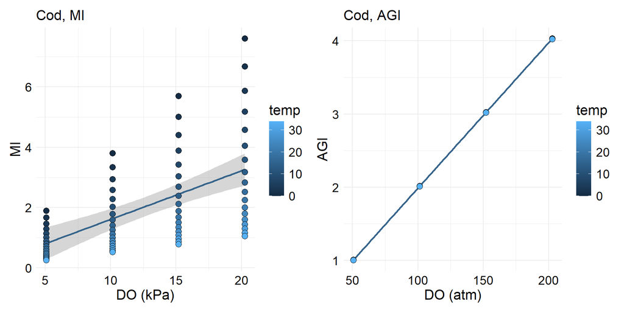

```r
cod_mi_do | cod_agi_do
```